# COVID-19 Model Fitting and Forecasting Report

Andrew Tredennick, Andreas Handel, and John Drake

24 April, 2020

```r
library(pomp)
library(tidyverse)
library(here)
library(googlesheets4)
```

## Overview

Given the importance of the COVID-19 pandemic and the the various difficulties inherent in fitting the transmission model, we will use three different methods of inference. First, we will use maximum likelihood by iterated filtering (MIF) to quickly hone in on the likelihood surface. Second, we will use particle MCMC to estimate uncertainty around parameter estimates, using the MIF MLEs as starting points for the MCMC. We will also employ informative priors to make parameters identifiable. Third, and in parallel to the pMCMC, we will use Approximate Bayesian Computation (ABC-MCMC) to also estimate uncertainty around parameters. In concert, the three methods of model fitting should allow us to make robust inference on model parameters and, in turn, generate meaningful forecasts with clearly propagated uncertainty. All model simulation and inference will use `pomp` functions.

## The Model

### Model Overview

This model tracks susceptibles, pre-symptomatic, asymptomatic, symptomatic, diagnosed, hopspitalized, dead and recovered hosts. The following compartments are included:

- **S** - uninfected and susceptible individuals
- **E** - individuals who are infected and do not yet show symptoms. Those individuals can be infectious.
- **I<sub>a</sub>** - individuals who are infected and do not show symptoms. Those individuals are likely infectious, but the model allows to adjust this.
- **I<sub>su</sub>** - individuals who are infected and show symptoms. Those individuals are likely infectious. Individuals in this compartment never get diagnosed and recover.
- **I<sub>sd</sub>** - individuals who are infected and show symptoms. Those individuals are likely infectious. Individuals in this compartment will get diagnosed and move to **C**.
- **C** - individuals who have been diagnosed as cases. Those individuals are likely isolated and not infectious, but the model allows to adjust this.
- **H** - individuals who have been hospitalized. Those individuals are likely isolated and not infectious, but the model allows to adjust this.
- **R** - recovered/removed individuals. Those individuals have recovered and are immune.
- **D** - individuals who died from the infection.

To allow more realistic distributions of movement through compartments, several of these compartments are internally split into dummy stages. Dummy stages are currently:

- **E** - 4 compartments
- **I<sub>a</sub>** - 4 compartments
- **I<sub>su</sub>** - 4 compartments
- **I<sub>sd</sub>** - 4 compartments
- **C** - 4 compartments
- **H** - 4 compartments

The included processes/mechanisms are the following:

- Susceptible individuals ($S$`) can become infected by individuals in the $E$, $I_a$, $I_s$, $I_d$, $C$, and $H$ stages. Rates of transmission from these stages can be adjusted individually.
- All infected hosts first enter the presymptomatic stage and move through the $E$ dummy compartments. At the end of the $E$ stage, a fraction moves into the $I_a$ stage, another fraction moves into the $I_{su}$ stage, the remainder into the $I_{sd}$ stage.
- Individuals in the asymptomatic $I_a$ stage are assumed to never be diagnosed and eventually recover.
- Individuals in the symptomatic $I_{su}$ stage are assumed to remain undiagnosed and eventually recover.
- Individuals in the symptomatic $I_{sd}$ stage are assumed to be diagnosed after some time and move into the $C$ stage.
- A fraction of individuals in the $C$ stage will naturally recover, without the need for hospitalization. The remainder moves into the $H$ stage.
- A fraction of individuals in the $H$ stage will recover, the remainder dies.

### Interventions

The following interventions are implemented:

- Social distancing, is assumed to reduce all transmission rates by some factor. This is provided as covariate based on mobility data.
- Increased speed of detection, which is assumed to increase at a sigmoidal manner up to a maximum value.
- Increased level of detection, which is assumed to increase the fraction of symptomatic individuals that move into the $I_{sd}$ compartment and will eventually be diagnosed. It is assumed to increase at a sigmoidal manner up to a maximum value.

### Model Implementation

The flow diagram for the model implemented in this app is:

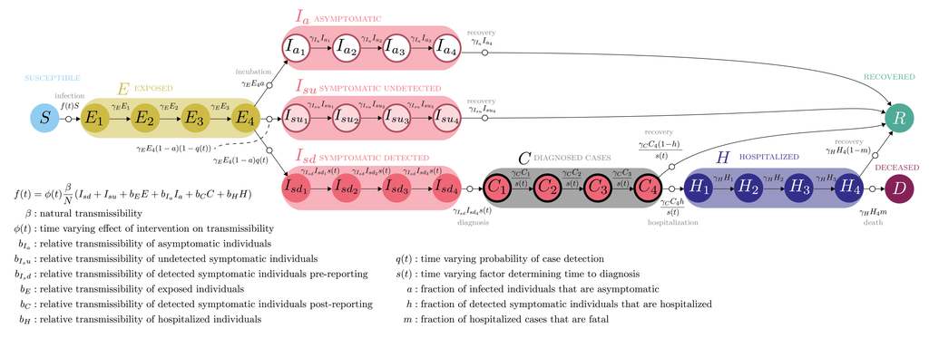

```r
knitr::include_graphics(here("docs",'pomp-model.png'))
```

### Model Parameters

| Parameter definition | Parameter symbol | Prior |
| --- | --- | --- |
| Transmission rate of symptomatic individuals (log) | log_beta_s | log(0.25/S_0); N(-17.56266, 0.5) |
| relative transmission of E class compared to Isu/Isd | trans_e | 2 |
| relative transmission of Ia class compared to Isu/Isd | trans_a | 0 |
| relative transmission of C class compared to Isu/Isd | trans_c | 1 |
| relative transmission of H class compared to Isu/Isd | trans_h | NULL |
| rate of movement through a single E stage (log) | log_g_e | log(4/4) |
| rate of movement through a single Ia stage (log) | log_g_a | log(4/3.5) |
| rate of movement through a single symptomatic undetected stage | log_g_su | log(4/6) |
| rate of movement through a single symptomatic detected stage | log_g_sd | log(4/3) |
| rate of movement through a single C stage (log) | log_g_c | log(4/3) |
| rate of movement through a single H stage (log) | log_g_h | log(4/12) |
| max factor by which diagnosis speeds up movement through Isd | log_max_diag | log(1) |
| rate at which increased detection factor ramps up | log_diag_inc_rate | log(10) |
| log time at which diagnse speedup is at half max | log_half_diag | log(12) |
| max fraction diagnosed (entering Isd) | max_detect_par | 0 |
| rate at which fraction diagnosed increases | log_detect_inc_rate | log(10) |
| log time at which detect fraction is at half max | log_half_detect | log(12) |
| fraction asymptomatic | frac_asym | 1.5 |
| fraction diagnosed cases who are hospitalized | frac_hosp | 3 |
| fraction hospitalized who die | frac_dead | 1.2 |
| observation dispersion | log_theta_cases | N(log(10), sd) |
| observation dispersion | log_theta_hosps | N(log(10), sd) |
| observation dispersion | log_theta_deaths | N(log(10), sd) |
| NA | NA | NULL |
| NA | NA | NULL |
| Number of susceptible persons | S | NULL |
| Number of exposed persons | E1 | Pois(40) |
| Number of exposed persons | E2 | Pois(40) |
| Number of exposed persons | E3 | Pois(40) |
| Number of exposed persons | E4 | Pois(40) |
| Asymptomatic individuals who will not be detected | Ia1 | Pois(22) |
| Asymptomatic individuals who will not be detected | Ia2 | Pois(22) |
| Asymptomatic individuals who will not be detected | Ia3 | Pois(22) |
| Asymptomatic individuals who will not be detected | Ia4 | Pois(22) |
| Symptomatic individuals who will not be detected | Isu1 | Pois(90) |
| Symptomatic individuals who will not be detected | Isu2 | Pois(90) |
| Symptomatic individuals who will not be detected | Isu3 | Pois(90) |
| Symptomatic individuals who will not be detected | Isu4 | Pois(90) |
| Symptomatic individuals who will be detected | Isd1 | Pois(14) |
| Symptomatic individuals who will be detected | Isd2 | Pois(14) |
| Symptomatic individuals who will be detected | Isd3 | Pois(14) |
| Symptomatic individuals who will be detected | Isd4 | Pois(14) |
| Detected/diagnosed invidiuals | C1 | NULL |
| Detected/diagnosed invidiuals | C2 | NULL |
| Detected/diagnosed invidiuals | C3 | NULL |
| Detected/diagnosed invidiuals | C4 | NULL |
| Hospitalized individuals | H1 | NULL |
| Hospitalized individuals | H2 | NULL |
| Hospitalized individuals | H3 | NULL |
| Hospitalized individuals | H4 | NULL |
| Dead individuals | D | NULL |
| Recovered individuals | R | NULL |

## Details for this model run

```r
#load data
filename = here('output','output_mif.rds')
mif_res <- readRDS(filename)
mifs = mif_res$mif_runs
pfs = mif_res$pf_runs
pomp_model = mif_res$pomp_model
pomp_data = mif_res$pomp_data
par_var_list = mif_res$par_var_list
datasource = mif_res$datasource
location = mif_res$location
traceplot = mif_res$traceplot
par_table = mif_res$partable
par_table_natural = mif_res$partable_natural
```

### Parameters to estimate

For this run, the following parameters and initial conditions are estimated:

```r
print(par_var_list$params_to_estimate)
```

```
##  [1] "log_beta_s"          "frac_hosp"           "frac_dead"
##  [4] "max_detect_par"      "log_detect_inc_rate" "log_half_detect"
##  [7] "log_sigma_dw"        "log_theta_cases"     "log_theta_hosps"
## [10] "log_theta_deaths"
```

```r
print(par_var_list$inivals_to_estimate)
```

```
## [1] ""
```

## Data and location

This run fits data from COV for state Georgia.

Data is retrieved and processed by scripts in the `data-processing` folder and saved to the `data` folder.

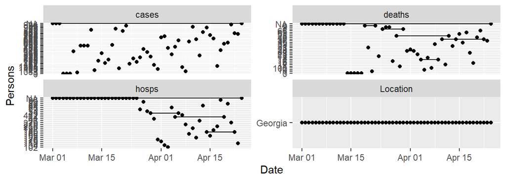

```r
# Plot the data to date
pl <- pomp_data %>%
  dplyr::select(-time) %>%
  gather(key = "Observation", value = "Persons", -Date) %>%
  ggplot(aes(x = Date, y = Persons)) +
  geom_line() +
  geom_point() +
  facet_wrap(~Observation, scales = "free_y")
plot(pl)
```

We also use data on traveling distance as a metric of social distancing. It is a relative metric ($\phi(t)$) that we assume linearly impacts the force of infection, such that the force of infection at time *t*, $f(t)$, is reduced to: $\phi(t) \times f(t)$. Here is $\phi(t)$ over time.

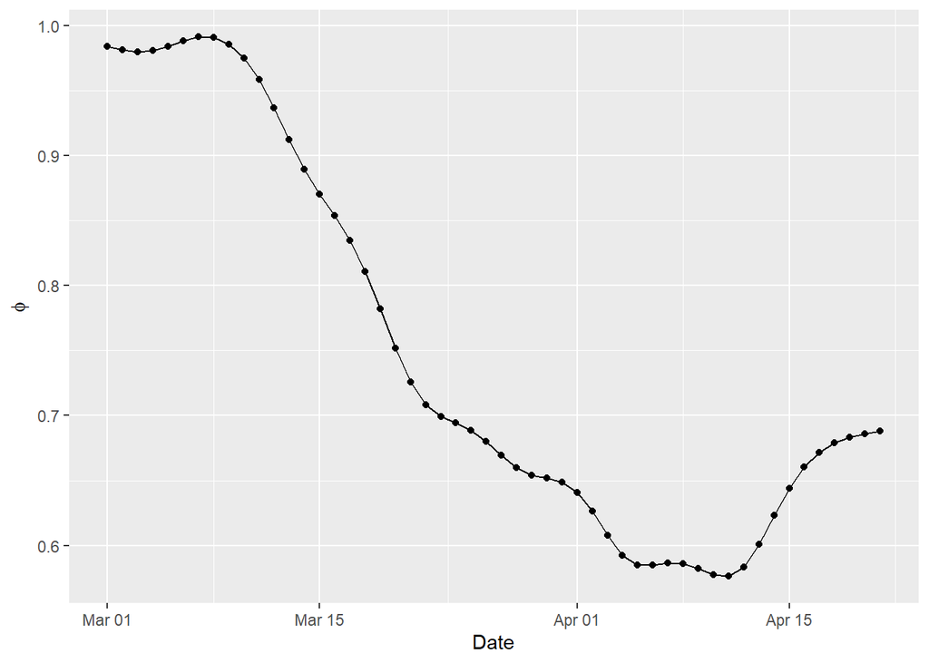

```r
phi <- readRDS(here('output',"rel-beta-change-covar.RDS")) %>%
  left_join(pomp_data %>%
              dplyr::select(Date, time), by = "time")

pl <- ggplot(data = phi, aes(x = Date, y = rel_beta_change)) +
  geom_line() +
  geom_point() +
  ylab(expression(phi))
plot(pl)
```

## Iterated filtering

We start the estimation procedure by using iterated filtering to find the maximum likelihood parameter estimates.

The parameters to be estimated are defined in the master script.

First, we look at the trace plots of those parameters which are estimated.

### MIF traces

This is generated by the `explore-mif-results` script.

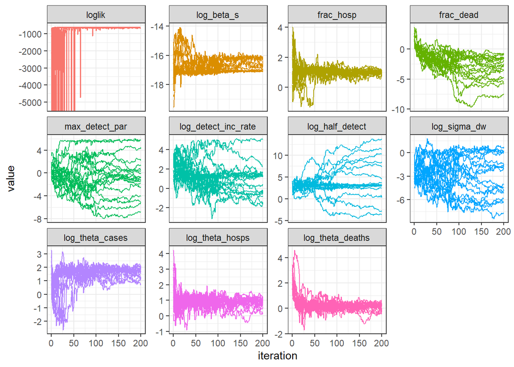

```r
plot(traceplot)
```

### Parameter and LL tables

We can look at estimated parameters and the LL for each MIF run. The table shows parameters as they are being fit. Columns are sorted by LL.

```r
table1 = data.frame(t(par_table))
knitr::kable(table1, caption = 'LL and parameters as estimated.')
```

LL and parameters as estimated.

|  | X1 | X2 | X3 | X4 | X5 | X6 | X7 | X8 | X9 | X10 | X11 | X12 | X13 | X14 | X15 | X16 | X17 | X18 | X19 | X20 |
| --- | --- | --- | --- | --- | --- | --- | --- | --- | --- | --- | --- | --- | --- | --- | --- | --- | --- | --- | --- | --- |
| MIF_ID | 9.0000000 | 1.0000000 | 20.0000000 | 11.0000000 | 17.0000000 | 2.0000000 | 15.0000000 | 4.0000000 | 19.0000000 | 6.0000000 | 3.0000000 | 18.0000000 | 8.0000000 | 12.0000000 | 10.0000000 | 14.0000000 | 7.0000000 | 16.0000000 | 5.0000000 | 13.0000000 |
| LogLik | -609.9301610 | -610.1557685 | -610.2771946 | -611.1701212 | -611.5950657 | -612.1378891 | -613.0179863 | -613.0776042 | -613.1419034 | -621.1007293 | -621.4050023 | -621.6914386 | -622.3336465 | -624.4234436 | -625.8991884 | -625.9238951 | -681.7639031 | -684.8263389 | -686.2091363 | -696.2142288 |
| LogLik_SE | 0.0655723 | 0.0772981 | 0.1823927 | 0.0522912 | 0.1116263 | 0.1335493 | 0.2226091 | 0.2420986 | 0.1637234 | 0.2340883 | 0.3136149 | 0.1011614 | 0.1896940 | 0.2081027 | 0.2016135 | 1.0548939 | 0.5950562 | 0.9520075 | 0.1274727 | 0.4193552 |
| log_beta_s | -17.0950395 | -17.0620091 | -17.0868360 | -17.0910534 | -17.0922861 | -17.0933395 | -17.1093421 | -17.1314493 | -17.1026483 | -16.2562837 | -16.9278312 | -16.1743028 | -16.6982908 | -16.3629616 | -17.0251690 | -16.7361437 | -16.2095289 | -16.2956158 | -16.1257242 | -16.0683117 |
| frac_hosp | 0.9152036 | 1.1074060 | 0.9476444 | 0.8655185 | 0.8456213 | 1.1394073 | 1.0659545 | 1.0771715 | 0.8023369 | 0.9805302 | 1.0071126 | 1.1164940 | 0.8552996 | 0.9562435 | 0.8153930 | 1.1586945 | 0.7788423 | 0.9772140 | 1.0745064 | 1.1697387 |
| frac_dead | -3.6065812 | -2.8477275 | -1.4675734 | -5.8479090 | -1.6869839 | -2.5138340 | -3.4347458 | -4.7778725 | -1.3918523 | -2.7011768 | -1.5762723 | -5.4122249 | -0.8052347 | -0.8601903 | -0.6650361 | -1.5182966 | -1.4381421 | -1.8699511 | -4.7664823 | -7.4621974 |
| max_detect_par | -1.2534790 | -0.7054478 | -0.6231403 | -2.3563300 | -0.8656379 | -4.0139295 | 0.0367101 | -5.0862779 | -1.2103125 | 5.8277548 | 0.4327994 | 5.8064661 | 1.2193638 | 4.5068721 | 0.2023959 | -5.0698735 | 2.3798852 | -1.3339269 | -1.7936324 | -6.8295709 |
| log_detect_inc_rate | 1.3972963 | 1.3794573 | 1.5038629 | 1.3107122 | 1.2431724 | 1.3872104 | 1.6158632 | 1.2031010 | 1.1682383 | 1.6212154 | -0.2776217 | 2.2272432 | -1.4418315 | -0.5633155 | -1.7208268 | 5.0600173 | -0.7805457 | -0.6095771 | -0.4753955 | 0.3932256 |
| log_half_detect | 3.1374063 | 3.0332667 | 3.0100163 | 3.2616249 | 3.1612529 | 3.2093815 | 2.8940917 | 3.2884898 | 3.2363363 | -3.5856464 | 4.5783319 | -2.8768142 | 8.5025789 | 0.2667910 | 3.7213756 | 2.4742400 | 10.3457633 | 13.8360579 | 11.4045996 | 7.3988442 |
| log_sigma_dw | -6.3814362 | -6.2227674 | -4.4013707 | -4.8663464 | -2.0421108 | -1.9331918 | -1.4131841 | -1.4057053 | -4.0973659 | 0.2339704 | -0.0918734 | 0.1752983 | 0.0103561 | 0.0905217 | -4.9007715 | 0.5392193 | -5.8305418 | -1.5989292 | -5.1726440 | -7.6873431 |
| log_theta_cases | 1.8669370 | 1.8926017 | 1.8600147 | 1.8602675 | 1.9981916 | 1.9034803 | 1.7130239 | 1.5469211 | 1.5922138 | 1.7597384 | 1.3144957 | 2.0390858 | 1.7754750 | 1.8070993 | 1.1759360 | 2.1485543 | 1.0789187 | 1.1507483 | 1.1117041 | 0.7490167 |
| log_theta_hosps | 1.0569017 | 1.2365665 | 1.2004680 | 0.9400183 | 0.7796970 | 0.8895291 | 0.9508175 | 0.8394354 | 0.7262935 | 0.7055241 | 1.1372716 | 0.6883139 | 0.7734811 | 1.1831079 | 0.7616903 | 1.2571867 | 0.1378804 | 0.5912513 | 0.8002358 | 0.1678730 |
| log_theta_deaths | 0.0395083 | 0.2087313 | 0.2100282 | 0.2045526 | 0.2628762 | -0.0418861 | 0.3654662 | 0.3951620 | 0.4249589 | 0.0374283 | 0.0946352 | -0.0782109 | 0.2823297 | 0.0403442 | 0.6536513 | 0.3133842 | -0.3792944 | -0.0592075 | -0.0846693 | -0.2473394 |

All parameters are fit on the real line and transformed inside the model. The table below transforms parameters to biologically more reasonable values. It shows all values for parameters, those fit and those not.

```r
knitr::kable(par_table_natural, caption = 'LL and parameters transformed to meaningful units.')
```

LL and parameters transformed to meaningful units.

|  | is_fitted | X1 | X2 | X3 | X4 | X5 | X6 | X7 | X8 | X9 | X10 | X11 | X12 | X13 | X14 | X15 | X16 | X17 | X18 | X19 | X20 |
| --- | --- | --- | --- | --- | --- | --- | --- | --- | --- | --- | --- | --- | --- | --- | --- | --- | --- | --- | --- | --- | --- |
| MIF_ID | no | 9.000000e+00 | 1.000000e+00 | 2.000000e+01 | 1.100000e+01 | 1.700000e+01 | 2.000000e+00 | 1.500000e+01 | 4.000000e+00 | 1.900000e+01 | 6.000000e+00 | 3.000000e+00 | 1.800000e+01 | 8.000000e+00 | 1.200000e+01 | 1.000000e+01 | 1.400000e+01 | 7.000000e+00 | 1.600000e+01 | 5.000000e+00 | 1.300000e+01 |
| LogLik | no | -6.099302e+02 | -6.101558e+02 | -6.102772e+02 | -6.111701e+02 | -6.115951e+02 | -6.121379e+02 | -6.130180e+02 | -6.130776e+02 | -6.131419e+02 | -6.211007e+02 | -6.214050e+02 | -6.216914e+02 | -6.223336e+02 | -6.244234e+02 | -6.258992e+02 | -6.259239e+02 | -6.817639e+02 | -6.848263e+02 | -6.862091e+02 | -6.962142e+02 |
| LogLik_SE | no | 6.557230e-02 | 7.729810e-02 | 1.823927e-01 | 5.229120e-02 | 1.116263e-01 | 1.335493e-01 | 2.226091e-01 | 2.420986e-01 | 1.637234e-01 | 2.340883e-01 | 3.136149e-01 | 1.011614e-01 | 1.896940e-01 | 2.081027e-01 | 2.016135e-01 | 1.054894e+00 | 5.950562e-01 | 9.520075e-01 | 1.274727e-01 | 4.193552e-01 |
| beta_s | yes | 0.000000e+00 | 0.000000e+00 | 0.000000e+00 | 0.000000e+00 | 0.000000e+00 | 0.000000e+00 | 0.000000e+00 | 0.000000e+00 | 0.000000e+00 | 1.000000e-07 | 0.000000e+00 | 1.000000e-07 | 1.000000e-07 | 1.000000e-07 | 0.000000e+00 | 1.000000e-07 | 1.000000e-07 | 1.000000e-07 | 1.000000e-07 | 1.000000e-07 |
| frac_trans_e | no | 1.192029e-01 | 1.192029e-01 | 1.192029e-01 | 1.192029e-01 | 1.192029e-01 | 1.192029e-01 | 1.192029e-01 | 1.192029e-01 | 1.192029e-01 | 1.192029e-01 | 1.192029e-01 | 1.192029e-01 | 1.192029e-01 | 1.192029e-01 | 1.192029e-01 | 1.192029e-01 | 1.192029e-01 | 1.192029e-01 | 1.192029e-01 | 1.192029e-01 |
| frac_trans_a | no | 5.000000e-01 | 5.000000e-01 | 5.000000e-01 | 5.000000e-01 | 5.000000e-01 | 5.000000e-01 | 5.000000e-01 | 5.000000e-01 | 5.000000e-01 | 5.000000e-01 | 5.000000e-01 | 5.000000e-01 | 5.000000e-01 | 5.000000e-01 | 5.000000e-01 | 5.000000e-01 | 5.000000e-01 | 5.000000e-01 | 5.000000e-01 | 5.000000e-01 |
| frac_trans_c | no | 2.689414e-01 | 2.689414e-01 | 2.689414e-01 | 2.689414e-01 | 2.689414e-01 | 2.689414e-01 | 2.689414e-01 | 2.689414e-01 | 2.689414e-01 | 2.689414e-01 | 2.689414e-01 | 2.689414e-01 | 2.689414e-01 | 2.689414e-01 | 2.689414e-01 | 2.689414e-01 | 2.689414e-01 | 2.689414e-01 | 2.689414e-01 | 2.689414e-01 |
| frac_trans_h | no | 4.540000e-05 | 4.540000e-05 | 4.540000e-05 | 4.540000e-05 | 4.540000e-05 | 4.540000e-05 | 4.540000e-05 | 4.540000e-05 | 4.540000e-05 | 4.540000e-05 | 4.540000e-05 | 4.540000e-05 | 4.540000e-05 | 4.540000e-05 | 4.540000e-05 | 4.540000e-05 | 4.540000e-05 | 4.540000e-05 | 4.540000e-05 | 4.540000e-05 |
| time_e | no | 4.000000e+00 | 4.000000e+00 | 4.000000e+00 | 4.000000e+00 | 4.000000e+00 | 4.000000e+00 | 4.000000e+00 | 4.000000e+00 | 4.000000e+00 | 4.000000e+00 | 4.000000e+00 | 4.000000e+00 | 4.000000e+00 | 4.000000e+00 | 4.000000e+00 | 4.000000e+00 | 4.000000e+00 | 4.000000e+00 | 4.000000e+00 | 4.000000e+00 |
| time_a | no | 3.500000e+00 | 3.500000e+00 | 3.500000e+00 | 3.500000e+00 | 3.500000e+00 | 3.500000e+00 | 3.500000e+00 | 3.500000e+00 | 3.500000e+00 | 3.500000e+00 | 3.500000e+00 | 3.500000e+00 | 3.500000e+00 | 3.500000e+00 | 3.500000e+00 | 3.500000e+00 | 3.500000e+00 | 3.500000e+00 | 3.500000e+00 | 3.500000e+00 |
| time_su | no | 6.000000e+00 | 6.000000e+00 | 6.000000e+00 | 6.000000e+00 | 6.000000e+00 | 6.000000e+00 | 6.000000e+00 | 6.000000e+00 | 6.000000e+00 | 6.000000e+00 | 6.000000e+00 | 6.000000e+00 | 6.000000e+00 | 6.000000e+00 | 6.000000e+00 | 6.000000e+00 | 6.000000e+00 | 6.000000e+00 | 6.000000e+00 | 6.000000e+00 |
| time_sd | no | 3.000000e+00 | 3.000000e+00 | 3.000000e+00 | 3.000000e+00 | 3.000000e+00 | 3.000000e+00 | 3.000000e+00 | 3.000000e+00 | 3.000000e+00 | 3.000000e+00 | 3.000000e+00 | 3.000000e+00 | 3.000000e+00 | 3.000000e+00 | 3.000000e+00 | 3.000000e+00 | 3.000000e+00 | 3.000000e+00 | 3.000000e+00 | 3.000000e+00 |
| time_c | no | 3.000000e+00 | 3.000000e+00 | 3.000000e+00 | 3.000000e+00 | 3.000000e+00 | 3.000000e+00 | 3.000000e+00 | 3.000000e+00 | 3.000000e+00 | 3.000000e+00 | 3.000000e+00 | 3.000000e+00 | 3.000000e+00 | 3.000000e+00 | 3.000000e+00 | 3.000000e+00 | 3.000000e+00 | 3.000000e+00 | 3.000000e+00 | 3.000000e+00 |
| time_h | no | 1.200000e+01 | 1.200000e+01 | 1.200000e+01 | 1.200000e+01 | 1.200000e+01 | 1.200000e+01 | 1.200000e+01 | 1.200000e+01 | 1.200000e+01 | 1.200000e+01 | 1.200000e+01 | 1.200000e+01 | 1.200000e+01 | 1.200000e+01 | 1.200000e+01 | 1.200000e+01 | 1.200000e+01 | 1.200000e+01 | 1.200000e+01 | 1.200000e+01 |
| max_diag_factor | no | 2.000000e+00 | 2.000000e+00 | 2.000000e+00 | 2.000000e+00 | 2.000000e+00 | 2.000000e+00 | 2.000000e+00 | 2.000000e+00 | 2.000000e+00 | 2.000000e+00 | 2.000000e+00 | 2.000000e+00 | 2.000000e+00 | 2.000000e+00 | 2.000000e+00 | 2.000000e+00 | 2.000000e+00 | 2.000000e+00 | 2.000000e+00 | 2.000000e+00 |
| diag_rampup | no | 1.000000e+01 | 1.000000e+01 | 1.000000e+01 | 1.000000e+01 | 1.000000e+01 | 1.000000e+01 | 1.000000e+01 | 1.000000e+01 | 1.000000e+01 | 1.000000e+01 | 1.000000e+01 | 1.000000e+01 | 1.000000e+01 | 1.000000e+01 | 1.000000e+01 | 1.000000e+01 | 1.000000e+01 | 1.000000e+01 | 1.000000e+01 | 1.000000e+01 |
| t_half_diag | no | 1.200000e+01 | 1.200000e+01 | 1.200000e+01 | 1.200000e+01 | 1.200000e+01 | 1.200000e+01 | 1.200000e+01 | 1.200000e+01 | 1.200000e+01 | 1.200000e+01 | 1.200000e+01 | 1.200000e+01 | 1.200000e+01 | 1.200000e+01 | 1.200000e+01 | 1.200000e+01 | 1.200000e+01 | 1.200000e+01 | 1.200000e+01 | 1.200000e+01 |
| max_detect_frac | yes | 7.779015e-01 | 6.693945e-01 | 6.509324e-01 | 9.134361e-01 | 7.038372e-01 | 9.822582e-01 | 4.908235e-01 | 9.938570e-01 | 7.703542e-01 | 2.936000e-03 | 3.934581e-01 | 2.999000e-03 | 2.280484e-01 | 1.091250e-02 | 4.495731e-01 | 9.937560e-01 | 8.471950e-02 | 7.914894e-01 | 8.573720e-01 | 9.989198e-01 |
| detect_rampup | yes | 4.044251e+00 | 3.972745e+00 | 4.499035e+00 | 3.708814e+00 | 3.466593e+00 | 4.003666e+00 | 5.032230e+00 | 3.330429e+00 | 3.216321e+00 | 5.059235e+00 | 7.575834e-01 | 9.274263e+00 | 2.364942e-01 | 5.693184e-01 | 1.789181e-01 | 1.575932e+02 | 4.581559e-01 | 5.435807e-01 | 6.216392e-01 | 1.481753e+00 |
| t_half_detect | yes | 2.304402e+01 | 2.076495e+01 | 2.028773e+01 | 2.609190e+01 | 2.360015e+01 | 2.476376e+01 | 1.806708e+01 | 2.680236e+01 | 2.544034e+01 | 2.771870e-02 | 9.735187e+01 | 5.631390e-02 | 4.927460e+03 | 1.305767e+00 | 4.132120e+01 | 1.187268e+01 | 3.112490e+04 | 1.020760e+06 | 8.973351e+04 | 1.634095e+03 |
| frac_asym | no | 1.824255e-01 | 1.824255e-01 | 1.824255e-01 | 1.824255e-01 | 1.824255e-01 | 1.824255e-01 | 1.824255e-01 | 1.824255e-01 | 1.824255e-01 | 1.824255e-01 | 1.824255e-01 | 1.824255e-01 | 1.824255e-01 | 1.824255e-01 | 1.824255e-01 | 1.824255e-01 | 1.824255e-01 | 1.824255e-01 | 1.824255e-01 | 1.824255e-01 |
| frac_hosp | yes | 2.859362e-01 | 2.483548e-01 | 2.793588e-01 | 2.961877e-01 | 3.003522e-01 | 2.424292e-01 | 2.561732e-01 | 2.540417e-01 | 3.095259e-01 | 2.727866e-01 | 2.675453e-01 | 2.466622e-01 | 2.983223e-01 | 2.776309e-01 | 3.067425e-01 | 2.389046e-01 | 3.145694e-01 | 2.734449e-01 | 2.545470e-01 | 2.369022e-01 |
| frac_dead | yes | 9.735729e-01 | 9.452011e-01 | 8.126883e-01 | 9.971224e-01 | 8.438271e-01 | 9.251060e-01 | 9.687730e-01 | 9.916563e-01 | 8.008878e-01 | 9.370961e-01 | 8.286759e-01 | 9.955581e-01 | 6.910931e-01 | 7.027004e-01 | 6.603908e-01 | 8.202875e-01 | 8.081668e-01 | 8.664526e-01 | 9.915615e-01 | 9.994259e-01 |
| theta_cases | yes | 6.468453e+00 | 6.636613e+00 | 6.423831e+00 | 6.425455e+00 | 7.375706e+00 | 6.709204e+00 | 5.545706e+00 | 4.696986e+00 | 4.914617e+00 | 5.810917e+00 | 3.722873e+00 | 7.683581e+00 | 5.903084e+00 | 6.092749e+00 | 3.241175e+00 | 8.572456e+00 | 2.941497e+00 | 3.160557e+00 | 3.039534e+00 | 2.114919e+00 |
| theta_hosps | yes | 2.877442e+00 | 3.443769e+00 | 3.321671e+00 | 2.560028e+00 | 2.180811e+00 | 2.433983e+00 | 2.587824e+00 | 2.315060e+00 | 2.067404e+00 | 2.024908e+00 | 3.118249e+00 | 1.990357e+00 | 2.167298e+00 | 3.264504e+00 | 2.141894e+00 | 3.515517e+00 | 1.147838e+00 | 1.806247e+00 | 2.226066e+00 | 1.182786e+00 |
| theta_deaths | yes | 1.040299e+00 | 1.232114e+00 | 1.233713e+00 | 1.226976e+00 | 1.300666e+00 | 9.589790e-01 | 1.441186e+00 | 1.484625e+00 | 1.529528e+00 | 1.038138e+00 | 1.099258e+00 | 9.247694e-01 | 1.326216e+00 | 1.041169e+00 | 1.922548e+00 | 1.368047e+00 | 6.843441e-01 | 9.425112e-01 | 9.188161e-01 | 7.808757e-01 |
| sigma_dw | yes | 1.692700e-03 | 1.983700e-03 | 1.226050e-02 | 7.701500e-03 | 1.297545e-01 | 1.446857e-01 | 2.433671e-01 | 2.451940e-01 | 1.661640e-02 | 1.263607e+00 | 9.122207e-01 | 1.191602e+00 | 1.010410e+00 | 1.094745e+00 | 7.440800e-03 | 1.714668e+00 | 2.936500e-03 | 2.021128e-01 | 5.669600e-03 | 4.586000e-04 |
| S_0 | no | 1.060000e+07 | 1.060000e+07 | 1.060000e+07 | 1.060000e+07 | 1.060000e+07 | 1.060000e+07 | 1.060000e+07 | 1.060000e+07 | 1.060000e+07 | 1.060000e+07 | 1.060000e+07 | 1.060000e+07 | 1.060000e+07 | 1.060000e+07 | 1.060000e+07 | 1.060000e+07 | 1.060000e+07 | 1.060000e+07 | 1.060000e+07 | 1.060000e+07 |
| E1_0 | no | 4.000000e+01 | 4.000000e+01 | 4.000000e+01 | 4.000000e+01 | 4.000000e+01 | 4.000000e+01 | 4.000000e+01 | 4.000000e+01 | 4.000000e+01 | 4.000000e+01 | 4.000000e+01 | 4.000000e+01 | 4.000000e+01 | 4.000000e+01 | 4.000000e+01 | 4.000000e+01 | 4.000000e+01 | 4.000000e+01 | 4.000000e+01 | 4.000000e+01 |
| Ia1_0 | no | 2.200000e+01 | 2.200000e+01 | 2.200000e+01 | 2.200000e+01 | 2.200000e+01 | 2.200000e+01 | 2.200000e+01 | 2.200000e+01 | 2.200000e+01 | 2.200000e+01 | 2.200000e+01 | 2.200000e+01 | 2.200000e+01 | 2.200000e+01 | 2.200000e+01 | 2.200000e+01 | 2.200000e+01 | 2.200000e+01 | 2.200000e+01 | 2.200000e+01 |
| Isu1_0 | no | 9.000000e+01 | 9.000000e+01 | 9.000000e+01 | 9.000000e+01 | 9.000000e+01 | 9.000000e+01 | 9.000000e+01 | 9.000000e+01 | 9.000000e+01 | 9.000000e+01 | 9.000000e+01 | 9.000000e+01 | 9.000000e+01 | 9.000000e+01 | 9.000000e+01 | 9.000000e+01 | 9.000000e+01 | 9.000000e+01 | 9.000000e+01 | 9.000000e+01 |
| Isd1_0 | no | 1.400000e+01 | 1.400000e+01 | 1.400000e+01 | 1.400000e+01 | 1.400000e+01 | 1.400000e+01 | 1.400000e+01 | 1.400000e+01 | 1.400000e+01 | 1.400000e+01 | 1.400000e+01 | 1.400000e+01 | 1.400000e+01 | 1.400000e+01 | 1.400000e+01 | 1.400000e+01 | 1.400000e+01 | 1.400000e+01 | 1.400000e+01 | 1.400000e+01 |
| C1_0 | no | 2.000000e+00 | 2.000000e+00 | 2.000000e+00 | 2.000000e+00 | 2.000000e+00 | 2.000000e+00 | 2.000000e+00 | 2.000000e+00 | 2.000000e+00 | 2.000000e+00 | 2.000000e+00 | 2.000000e+00 | 2.000000e+00 | 2.000000e+00 | 2.000000e+00 | 2.000000e+00 | 2.000000e+00 | 2.000000e+00 | 2.000000e+00 | 2.000000e+00 |
| H1_0 | no | 2.000000e+00 | 2.000000e+00 | 2.000000e+00 | 2.000000e+00 | 2.000000e+00 | 2.000000e+00 | 2.000000e+00 | 2.000000e+00 | 2.000000e+00 | 2.000000e+00 | 2.000000e+00 | 2.000000e+00 | 2.000000e+00 | 2.000000e+00 | 2.000000e+00 | 2.000000e+00 | 2.000000e+00 | 2.000000e+00 | 2.000000e+00 | 2.000000e+00 |
| R_0 | no | 0.000000e+00 | 0.000000e+00 | 0.000000e+00 | 0.000000e+00 | 0.000000e+00 | 0.000000e+00 | 0.000000e+00 | 0.000000e+00 | 0.000000e+00 | 0.000000e+00 | 0.000000e+00 | 0.000000e+00 | 0.000000e+00 | 0.000000e+00 | 0.000000e+00 | 0.000000e+00 | 0.000000e+00 | 0.000000e+00 | 0.000000e+00 | 0.000000e+00 |
| D_0 | no | 0.000000e+00 | 0.000000e+00 | 0.000000e+00 | 0.000000e+00 | 0.000000e+00 | 0.000000e+00 | 0.000000e+00 | 0.000000e+00 | 0.000000e+00 | 0.000000e+00 | 0.000000e+00 | 0.000000e+00 | 0.000000e+00 | 0.000000e+00 | 0.000000e+00 | 0.000000e+00 | 0.000000e+00 | 0.000000e+00 | 0.000000e+00 | 0.000000e+00 |

## Simulate/forecast from the MLEs

Next we run the pomp model (simulate it) and explore the simulations. This is done in simulate-pomp-model and explore-simulation-results. One can specify which parameter values to use for simulation.

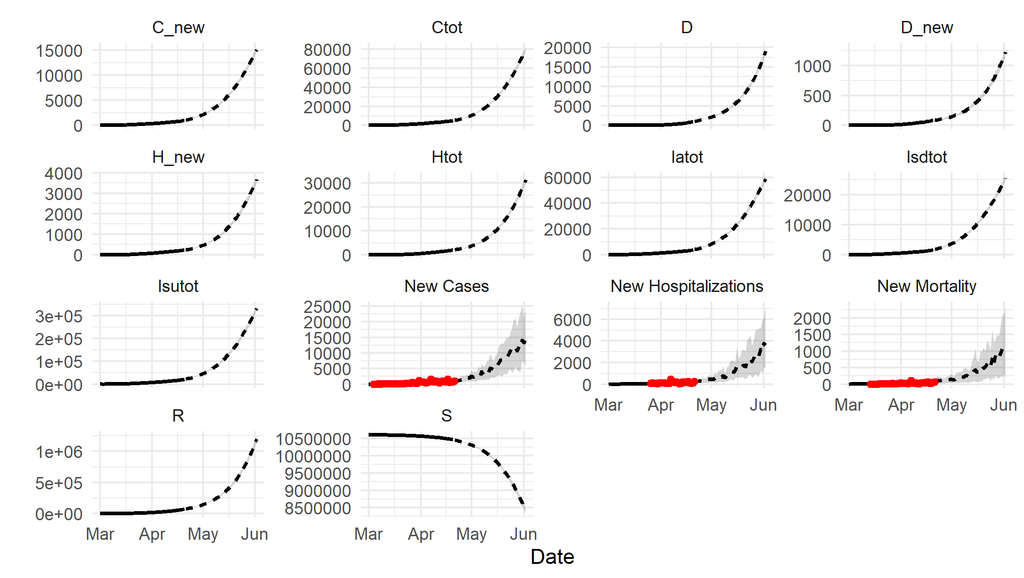

```r
knitr::include_graphics(here('output/figures/traj-plot.png'))
```

This plot shows just those variables which are fit.

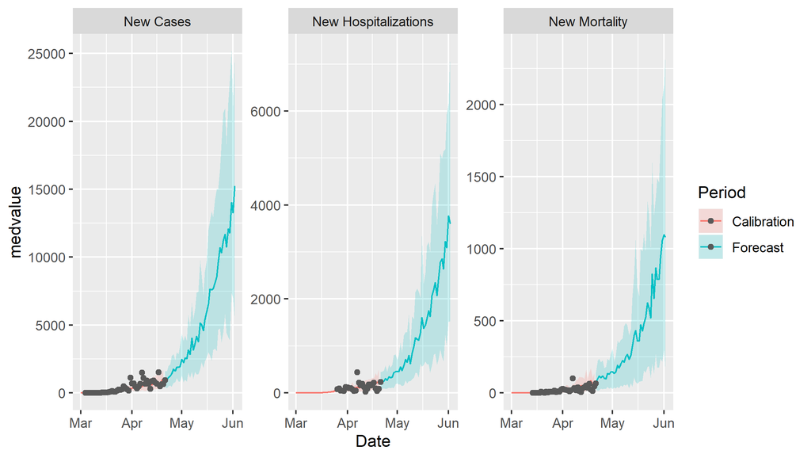

```r
knitr::include_graphics(here('output/figures/fit-plot.png'))
```

## Likelihood slice

```r
#knitr::include_graphics(here('output/figures/LL-slice.png'))
```